# PZ_2_Klingen

## Практична робота №2.Асимптотична складність алгоритмів. Інші нотації

## Author - Kyrylo Klingen

**Мета:** *набути практичних навичок у розв’язанні задач на оцінку асимптотичної складності алгоритмів у Ω, Θ, 𝜊, 𝜃, 𝜔-нотаціях.*

## 1.Ознайомлення з роздатковим матеріалом та прикладами рішення.

## 2.Виконання завдання (номер 8 та 13).

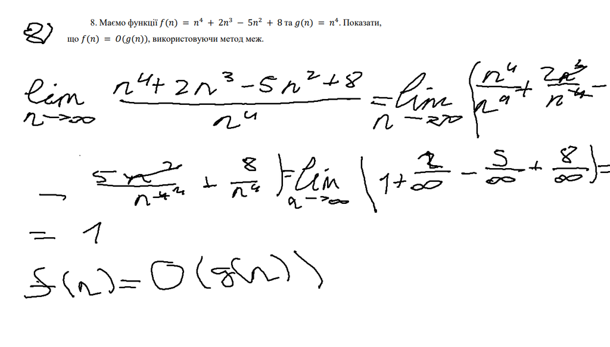

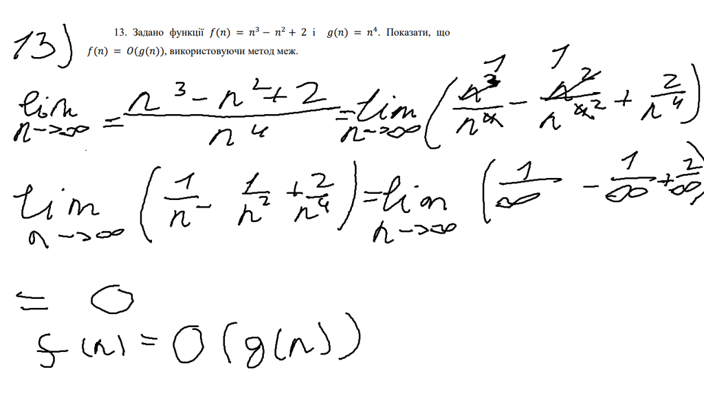

## 3.Контрольні питання.

- Що таке асимптотична складність алгоритму? - .Асимптотична складність алгоритму це характеристика , яка визначає відношення часу виконання певної дії до кількості вхідних даних у алгоритмі.
- Які інші нотації, крім O-нотації, використовуються для вираження асимптотичної складності? - Ω (Омега-нотація) Θ (Тета-нотація) o (Мала о-нотація)ω (Мала омега-нотація) .
- Як визначити асимптотичну складність алгоритму за допомогою символів Θ і Ω? - (Омега нотація) Нехай 𝑓 і 𝑔 – дві функції, що відображають натуральні числа на додатні дійсні числа. Тоді 𝑓(𝑛) = Ω(𝑔(𝑛)), якщо ∃ 𝑐 > 0 та натуральна константа 𝑛0, така, що 𝑓(𝑛) ≥ 𝑐𝑔(𝑛) для ∀𝑛 ≥ 𝑛0. (Тета-нотація) Нехай 𝑓 та 𝑔 – функції натурального аргумента і дійсних значень. Тоді 𝑓(𝑛) = Θ(𝑔(𝑛)), якщо ∃ дійсні 𝑐1, 𝑐2 > 0 та натуральна константа 𝑛0, така, що 𝑐1𝑔(𝑛) ≤ 𝑓(𝑛) ≤ 𝑐2𝑔(𝑛) для ∀𝑛 ≥ 𝑛0 .
- Яка різниця між O-нотацією, Θ-нотацією і Ω-нотацією? - О-нотація визначає верхню межу алгоритму.Θ-нотація визначає верхню і нижню межу алгоритму Ω-нотація визначає нижню межу алгоритму.
- Які основні властивості інших нотацій, таких як o (маленька о), ω (маленька омега) та 𝑜 (маленька о з верхнім індексом)? - маленька о нотація позначає менше зростання(рівності бути не може) маленька ω нотація - позначає більше зростання (рівності бути не може) маленька о з верхнім індексом - позначення дуже швидкого спадання відносно іншої функції.